# Final_assignment

2024-01-08

The running time of the code is long. Therefore, I have commented out the codes that have created the meta data sets in the code appendix. I have saved these data frames to csv files in my git repository through which it can be downloaded. The link to my repository is: https://github.com/aashikachoudhary22/Final_Assignment-MY472-.git

# Introduction:

The research question aims to understand if any factors differentiate between British MPs who ask economic questions in comparison to MPs who ask health and welfare-related questions. In order to answer this question, I have looked at both oral and written questions asked by MPs and segmented the MPs on factors such as gender, party, minority status, region representation and region specific median wage. The key metric I have created in my analysis is the ratio of the total number of economic questions to health and welfare questions asked by MPs within each segment. This ratio enables us to understand if any groups of MPs tend to favor any particular category of question. I have assessed this metric over time between 2019 and 2020 to understand if the onset of covid-19 had caused any difference in the observation.

# Data:

The functions I created extracted up to 100 oral questions and up to 100 written questions for each month between January 2019 and December 2020. I have assumed that the API has provided me with a random selection of questions from each month which ensures that the dataset used is representative.

In order to determine whether a question is related to health and welfare or the economy, I created a vocabulary of words for each of the two categories. If a word from a vocabulary occurred in a question then it was assigned to the relevant category. The vocabularies are a combination of some general words and others that had been in the news during 2019-2020. Eg: Brexit, inflation, bank rates, recession, oil prices, GPD, trade wars had accounted for the most economic conversations in these two years. For health and welfare, it was the welfare cuts of 2019, mental health, impact of digital platforms, knife crime, climate change, covid-19’s impact on hospitals, education, etc. I have not added the words “covid” or “pandemic” to any of the vocabularies because these words were used in the context of both economic and health and welfare-related conversations.

Next, I used the quanteda package to create a corpus from the questions obtained from the API. I then convert the corpus into a document matrix through which I look for the words mentioned from the vocabularies. I obtained additional MP data from the API including MP name, gender, party and constituency, and accessed some additional data sources - ethnic minority status of MPs via Wikipedia and median income for each constituency (2023) obtained via a file from the House of Commons Library.

I have 2 final datasets - one for economic questions and one for health and welfare questions across 2019 and 2020. Both of these also contain the relevant MP metadata. I then group by month and the necessary factors and calculate the ratio of number of economic questions asked to number of health and welfare questions asked, before creating the relevant plots.

```
## [1] "Sample rows from economic data set"
```

```
##   credit poverty payment bank industry manufacturing fiscal growth money cost
## 1      0       0       0    0        0             0      0      0     0    0
##   market salary services rent infrastructure business job tax economy
## 1      0      1        0    0              0        0   0   0       0
##   unemployment loss budget workers income pension revenue pay trade cash rate
## 1            0    0      0       0      0       0       0   0     0    0    0
##   brexit inflation gdp deficit oil dollar surplus Member_ID    Date
## 1      0         0   0       0   0      0       0      4420 2019-01
##      Member_name Gender                   party                   constituency
## 1 Gavin Newlands      M Scottish National Party Paisley and Renfrewshire North
##   RegionName WageMedianConst WageMedianRegion Minority_indicator
## 1   Scotland             802              702                  0
```

```
## [1] "Sample rows from health data set"
```

```
##   childcare children care gender women security abuse education sustainability
## 1         0        0    0      0     0        0     0         1              0
##   school service criminal safety prison girls homelessness housing plastic
## 1      0       0        0      0      0     0            0       0       0
##   theft immigration climate aid pollution patients mental university hospital
## 1     0           0       0   0         0        0      0          0        0
##   digital vulnerable disabled water welfare knife refugee old electricity
## 1       0          0        0     0       0     0       0   0           0
##   Member_ID    Date  Member_name Gender  party            constituency
## 1      4389 2019-01 Ruth Cadbury      F Labour Brentford and Isleworth
##   RegionName WageMedianConst WageMedianRegion Minority_indicator
## 1     London             849              796                  0
```

# Analysis:

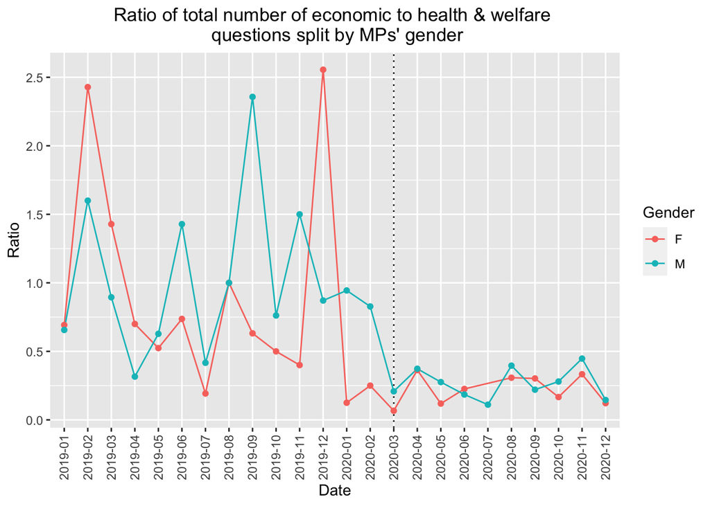

In the above plot, it is observed that men in general have marginally asked more economy-related questions in comparison to women. Post the onset of covid-19, both genders have actively asked more questions about health but we cannot see a big difference in the ratio of questions asked by the two genders.

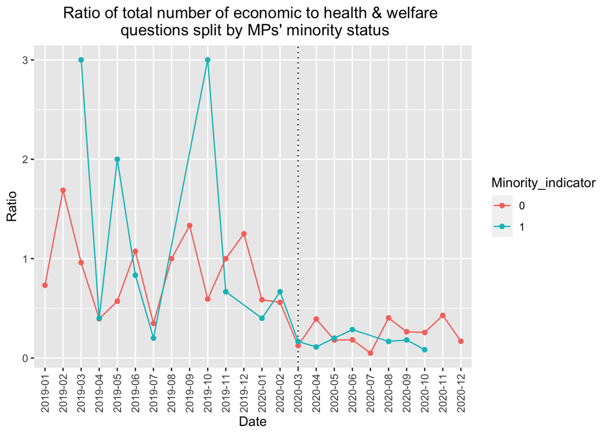

In the plot above, prior to the onset of covid-19, there are no clear trends between the kind of questions asked by MPs with a minority status compared to MPs without one. However, post the onset of the pandemic, MPs with minority status have asked more health-related questions when compared to MPs without one.

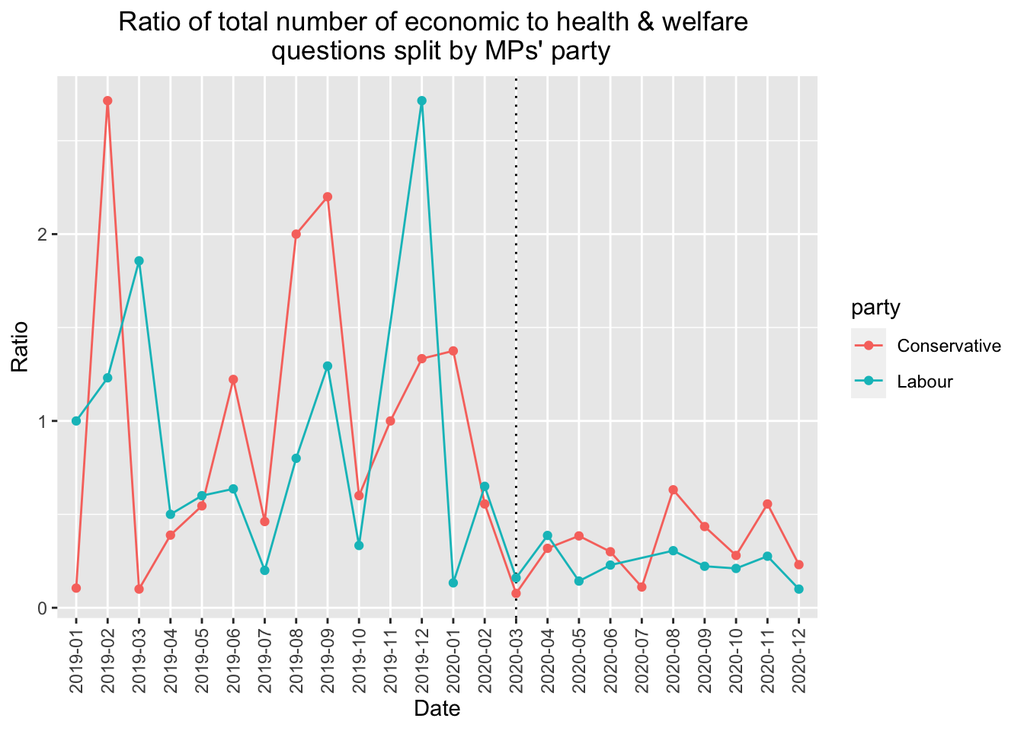

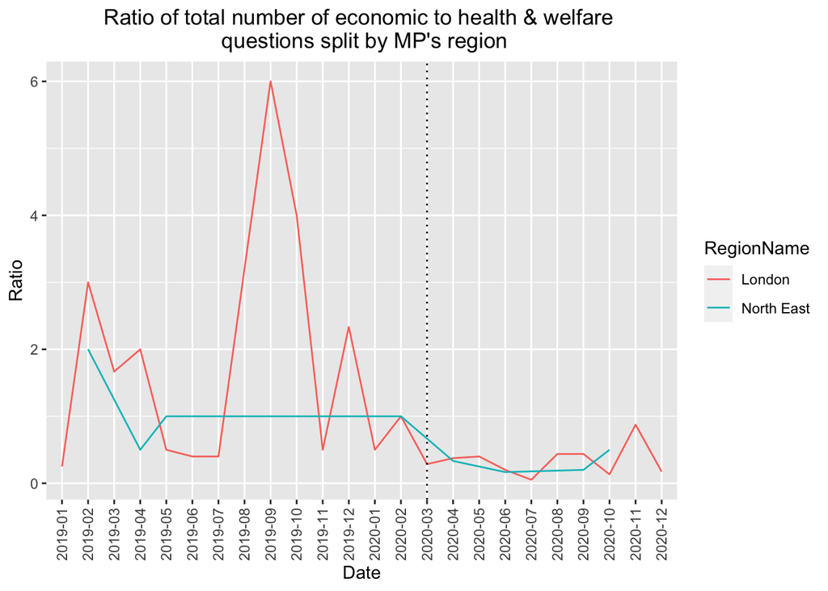

```
## geom_point: na.rm = FALSE
## stat_identity: na.rm = FALSE
## position_identity
```

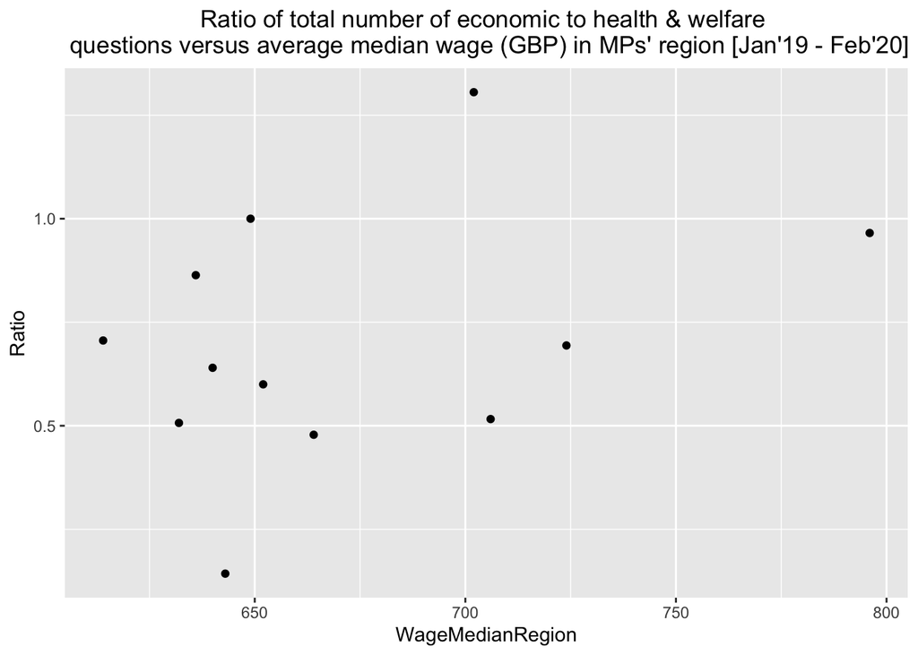

Through the plot, it can be seen that there is no clear correlation with regards to the kind of questions asked and the median wage of regions that the MPs represent. Most of the questions asked are closer to health and welfare category along with some outliers.

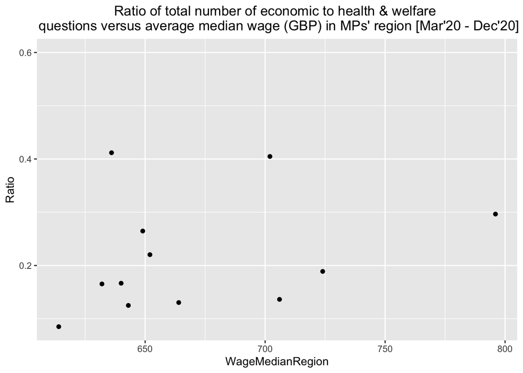

# Appendix: All code in this assignment

```
#setwd("/Users/aashikachoudhary/Desktop/MY472/Final_Assignment-MY472-")
#write.csv(economic_data, "economic_data.csv", row.names = FALSE)
#write.csv(health_data, "health_data.csv", row.names = FALSE)

economic_data_csv <- read.csv("economic_data.csv")
health_data_csv <- read.csv("health_data.csv")

# A function which takes a list of "start_date" and "end_date" as inputs to give a list of oral_questions asked by British MPs
#oral_questions <- function(start_dates, end_dates) {
# Creating an empty list to store results for each date range
 # all_questions <- list()
  # For loop to iterate over dates
 # for (i in seq_along(start_dates)) {
    # Defining the url
   # url <- "https://oralquestionsandmotions-api.parliament.uk/oralquestions/list?parameters.answeringDateStart="
    # Redefining the url along with pasting value from the url, the start and the end date
   # url <- paste0(url, start_dates[i], "&parameters.answeringDateEnd=", end_dates[i], "&parameters.take=100")
    # Converting the url into json
   # json.m <- fromJSON(url)

    # Check if 'Response' is present in json.m and has the expected data structure
   # if ("Response" %in% names(json.m) && is.data.frame(json.m$Response)) {
      # If the condition in the "if" statement is true then assigning data to the following
    #  data <- json.m$Response[, c("QuestionText", "TabledWhen", "AskingMemberId")]
    #  all_questions[[i]] <- data
   # } else {
      # Handle unexpected structure or missing 'Response'
     # warning(paste("Unexpected structure in response for dates:", start_dates[i], "to", end_dates[i]))
      #The i(th) elment of "all_questions" list is assigned to a vector containing three NA values
     # all_questions[[i]] <- c(NA, NA, NA)
   # }
 # }
  # Filter out all elements which are not null and assigning it to "all_questions"
 # all_questions <- Filter(Negate(is.null), all_questions)
  # "all_questions" only contains non null elements and stop the execution of the error message
  # if (length(all_questions) == 0) {
   # stop("No valid data found.")
 # }
  # returning the elements of "all questions" into a single dataframe
 # return(do.call(rbind, all_questions))
```

[output cut: 378 more lines]

```
  summarise(num_health_questions=n())

# Merging total gender count of both economic and health data grouped by date and gender into a new data set
economic_health_region <- merge(economic_totalregion_count, health_totalregion_count, by = c("Date", "RegionName"))
# Creating a new column in this data set which is a ratio of total number of economic to health questions segregated by gender
economic_health_region$Ratio <- economic_health_region$num_economic_questions/economic_health_region$num_health_questions

# Creating a plot which has Date on x-axis, ration on y-axis and it is grouped by gender
ggplot(economic_health_region, aes(x = Date, y = Ratio, col = RegionName, group = RegionName)) +
  geom_line()+
  theme(axis.text.x = element_text(angle=90, vjust=.5, hjust=1)) +
  geom_vline(xintercept = "2020-03", linetype = "dotted", color = "black") +
  ggtitle("Ratio of total number of economic to health & welfare \n questions split by MP's region") +
  theme(plot.title = element_text(hjust = 0.5))
  geom_point()
```